# The Development Gap in Economic Rationality of Future Elites

Erik Ø. Sørensen

08 september, 2023

# Reading data

```r
tar_load(df)
tar_load(studysubjects_categorized)
```

# Summaries of background data

## Experiment data

```r
df %>% group_by(country) %>%
  summarize(n = n(),
            one_parent_college = mean(one_parent_college, na.rm=TRUE),
            female = mean(sex==2, na.rm=TRUE),
            age = mean(age, na.rm=TRUE),
            worried = mean(yworried, na.rm=TRUE),
            happiness = mean(happy, na.rm=TRUE),
            government_preference = mean(government_preference=="Yes", na.rm=TRUE)) |>
  gt::gt() |>
  gt::fmt_number(columns = c(one_parent_college, female, worried, happiness, government_preference), decimals = 3) |>
  gt::fmt_number(columns = c(happiness), decimals = 2) |>
  gt::fmt_number(columns = age, decimals=1) |>
  gt::fmt_number(columns=n, decimals=0)
```

| Country of experiment | n | one_parent_college | female | age | worried | happiness | government_preference |
| --- | --- | --- | --- | --- | --- | --- | --- |
| United States | 126 | 0.825 | 0.706 | 20.6 | 0.310 | 7.41 | 0.381 |
| Tanzania | 216 | 0.307 | 0.336 | 23.3 | 0.181 | 6.64 | 0.274 |

## Follow up survey in Tanzania

```r
tar_load(tanzaniasurvey)
tz_df <- tanzaniasurvey
```

### Where are they from?

There are 32 **regions** in Tanzania (three of them on Zanzibar). We have manually classified self-reported (free-form) birthplace to official region names.

```r
tz_df %>% group_by(birth_region) %>%
  summarize( n = n()) %>%
  arrange(-n) %>%
  mutate( proportion = n/sum(n),
          ranking = row_number()) %>%
  gt::gt() |>
  gt::fmt_number(columns = c(n, ranking), decimals = 0) |>
  gt::fmt_number(columns = c(proportion), decimals = 3)
```

| 1.5 (Recoding of) self-reported birthplace | n | proportion | ranking |
| --- | --- | --- | --- |
| Kagera | 37 | 0.172 | 1 |
| Dar es Salaam | 36 | 0.167 | 2 |
| Kilimanjaro | 29 | 0.135 | 3 |
| Mbeya | 13 | 0.060 | 4 |
| Mara | 10 | 0.047 | 5 |
| Shinyanga | 9 | 0.042 | 6 |
| Arusha | 8 | 0.037 | 7 |
| Kigoma | 8 | 0.037 | 8 |
| Mwanza | 8 | 0.037 | 9 |
| Tanga | 8 | 0.037 | 10 |
| Dodoma | 6 | 0.028 | 11 |
| Iringa | 6 | 0.028 | 12 |
| Njombe | 6 | 0.028 | 13 |
| Mtwara | 5 | 0.023 | 14 |
| Rukwa | 5 | 0.023 | 15 |
| Ruvuma | 4 | 0.019 | 16 |
| Singida | 4 | 0.019 | 17 |
| Tabora | 4 | 0.019 | 18 |
| Katavi | 2 | 0.009 | 19 |
| Simiyu | 2 | 0.009 | 20 |
| Lindi | 1 | 0.005 | 21 |
| Manyara | 1 | 0.005 | 22 |
| Morogoro | 1 | 0.005 | 23 |
| Songwe | 1 | 0.005 | 24 |
| Zanzibar | 1 | 0.005 | 25 |

Note that the one “Zanzibar” response is not allocated to a proper region, as no more information than “Zanzibar” was given by the respondent.

While the participants at lab experiments at major American universities have been extensively studied, our sample at the University of Dar-es-Salaam comes from a less studied population, and not from a permanent pool of lab experiments. We implemented a small survey of our Tanzanian lab participants (on 215 out of our 216 lab participants).

While the university is located in Dar-es-Salaam, we have participants from 25 out of the 30 Tanzanian regions (as of 2012). Those born in Dar-es-Salaam are well represented (16.7 %), but there are slightly more from Kagera (17.2%) and almost as many from Kilimanjaro (13.5 %). There are 6% or less from each of the other regions.

### Regional (PPP) GDP / capita

The regional GDPs per capita are reported in Table 22 of

- [NATIONAL ACCOUNTS STATISTICS OF TANZANIA MAINLAND 2012-2018. First Edition IN THE REVISED GDP SERIES BASE YEAR 2015](https://www.nbs.go.tz/nbs/takwimu/na/National_Accounts_Statistics_of_Tanzania_Mainland_2018.pdf).

Punching the 2012 GDP per capita at current prices

```r
TZ_GDP <- tribble(~region, ~gdp2012,
                  "Dodoma", 927536,
                  "Arusha",1754637,
                  "Kilimanjaro", 1725950,
                  "Tanga", 1431271,
                  "Morogoro", 1373059,
                  "Pwani", 1048866,
                  "Dar es salaam", 2419087,
                  "Lindi", 1361215,
                  "Mtwara", 1298007,
                  "Ruvuma", 1726244,
                  "Iringa", 1991561,
                  "Mbeya", 1687330,
                  "Singida", 872866,
                  "Tabora", 1074905,
                  "Rukwa", 1358997,
                  "Kigoma", 848712,
                  "Shinyanga", 1124625,
                  "Kagera", 869527,
                  "Mwanza", 1450639,
                  "Mara", 1319264,
                  "Manyara", 1461955)
```

For all of the mainland, the number was

```r
gdp_tz_mainland <- 1429327
```

The [GDP per capita, PPP (constant 2017 international $) for Tanzania, according to the World Bank](https://data.worldbank.org/indicator/NY.GDP.PCAP.PP.KD?locations=TZ) was

```r
gdp_tz_wbPPP <- 2094
```

Using the national numbers to compute a national correction factor, we get the PPP adjusted GDP/capita 2012 in 2017 international dollars:

```r
TZ_GDP |> mutate(gdp2012ppp = (gdp2012 / gdp_tz_mainland) * gdp_tz_wbPPP) |>
  arrange(-gdp2012ppp) |>
  mutate(rank = row_number()) |>
  dplyr::select(-gdp2012) |>
  gt::gt() |>
  gt::fmt_number(columns=gdp2012ppp, decimals = 0, use_seps = TRUE)
```

| region | gdp2012ppp | rank |
| --- | --- | --- |
| Dar es salaam | 3,544 | 1 |
| Iringa | 2,918 | 2 |
| Arusha | 2,571 | 3 |
| Ruvuma | 2,529 | 4 |
| Kilimanjaro | 2,529 | 5 |
| Mbeya | 2,472 | 6 |
| Manyara | 2,142 | 7 |
| Mwanza | 2,125 | 8 |
| Tanga | 2,097 | 9 |
| Morogoro | 2,012 | 10 |
| Lindi | 1,994 | 11 |
| Rukwa | 1,991 | 12 |
| Mara | 1,933 | 13 |
| Mtwara | 1,902 | 14 |
| Shinyanga | 1,648 | 15 |
| Tabora | 1,575 | 16 |
| Pwani | 1,537 | 17 |
| Dodoma | 1,359 | 18 |
| Singida | 1,279 | 19 |
| Kagera | 1,274 | 20 |
| Kigoma | 1,243 | 21 |

### Field of study

For a more detailed look at the subjects they studied, let’s count the number that in some way reported to have economics as part of their degree.

```r
cat_table <- studysubjects_categorized |>
  mutate(contains_economic = str_detect(studysubject, regex("economic", ignore_case = TRUE))) |>
  group_by(contains_economic) |>
  group_by(category) |>
  summarize(n  = sum(n_responses),
            cond_prop_econ = mean(contains_economic)) |>
  mutate(proportion = n/sum(n)) |>
  arrange(-proportion) |>
  dplyr::select(c(category, proportion, cond_prop_econ)) |>
  gt::gt() |>
  gt::fmt_number(columns=c(proportion, cond_prop_econ), decimals = 3)
cat_table
```

| category | proportion | cond_prop_econ |
| --- | --- | --- |
| social science | 0.447 | 0.200 |
| science and engineering | 0.293 | 0.000 |
| education | 0.098 | 0.167 |
| humanities | 0.088 | 0.000 |
| business management | 0.037 | 0.000 |
| law | 0.037 | 0.000 |

```r
cat_table |> as_latex() |>
  as.character() |>
  writeLines(con = here::here("tables","studysubjects.tex"))
```

### Financing of expenses

The median reported yearly expenses was 2000000 TZS, corresponding to about 1200 USD at 2012 exchange rates.

For a fuller analysis of sources of finance, with all non-reported category observations set to zero:

```r
income_table <- tanzaniasurvey |>
  dplyr::select(c(survey_id, ann_finance1, ann_finance2, ann_finance3, ann_finance4,
                  ann_finance5, ann_finance6, ann_finance7, ann_finance8)) |>
  pivot_longer(starts_with("ann_finance")) |>
  mutate(amount = ifelse(!is.na(value),value,0),
         name = factor(name),
         source = fct_recode(name,
                             "Government support/loan" = "ann_finance1",
                             "Support from family" = "ann_finance2",
                             "Loan from family" = "ann_finance3",
                             "Own work" = "ann_finance4",
                             "Scholarship grant" = "ann_finance5",
                             "Other grants" = "ann_finance6",
                             "Support from NGO" = "ann_finance7",
                             "Other" = "ann_finance8"),
         nonzero = as.numeric(amount>0)) |>
  group_by(survey_id) |>
  mutate( share = amount / sum(amount)) |>
  group_by(source) |>
  summarize(share_with_positive = mean(nonzero),
            mean_share = mean(share, na.rm=TRUE)) |>
  arrange(-share_with_positive) |>
  dplyr::select(c(source, share_with_positive, mean_share)) |>
  gt::gt() |> gt::fmt_number(decimals=3)
income_table
```

| source | share_with_positive | mean_share |
| --- | --- | --- |
| Government support/loan | 0.916 | 0.645 |
| Support from family | 0.805 | 0.232 |
| Own work | 0.251 | 0.042 |
| Other grants | 0.233 | 0.030 |
| Loan from family | 0.135 | 0.018 |
| Other | 0.098 | 0.012 |
| Support from NGO | 0.051 | 0.010 |
| Scholarship grant | 0.047 | 0.011 |

```r
income_table |>
  as_latex() |>
  as.character() |>
  writeLines(con=here::here("tables","budgetshares.tex"))
```

We also have a couple of more specific questions about support:

```r
tz_df |> summarize(any_familysupport = mean(familysupport),
                   mean_familysupport = mean(familysupport_value, na.rm=TRUE),
                   median_familysupport = median(familysupport_value, na.rm=TRUE)) |>
  gt::gt() |>
  gt::fmt_number(columns = any_familysupport, decimals = 3) |>
  gt::fmt_number(columns = c(mean_familysupport,median_familysupport), decimals=0)
```

| any_familysupport | mean_familysupport | median_familysupport |
| --- | --- | --- |
| 0.805 | 80,498 | 30,000 |

And for government loans

```r
tz_df |>
  summarize(mean_govloan = mean(govloan>0, na.rm=TRUE),
            mean_govloanshare = mean(govloan, na.rm=TRUE)) |>
  gt::gt() |> gt::fmt_number(decimals=3)
```

| mean_govloan | mean_govloanshare |
| --- | --- |
| 0.930 | 68.630 |

# Descriptives of behavioral outcomes

## Means of the main outcomes

Overall means for a striking first figure of the rationalizability scores. First, calculate the means and standard errors for both the original and the standardized scores.

```r
tar_load(fig_dta)
```

What are the levels in each country and the level differences:

```r
fig_dta |> dplyr::select(country, outcome_nm, mean) |>
  pivot_wider(id_cols=outcome_nm, names_from = country, values_from = mean) |>
  mutate(difference = `United States` - Tanzania) |>
  gt::gt() |>
  gt::fmt_number(columns=c(Tanzania, `United States`), decimals=2) |>
  gt::fmt_number(columns=difference, decimals=3)
```

| outcome_nm | United States | Tanzania | difference |
| --- | --- | --- | --- |
| e* | 0.95 | 0.86 | 0.088 |
| e** | 0.90 | 0.75 | 0.142 |
| e*** | 0.89 | 0.75 | 0.140 |
| iq | 0.86 | 0.49 | 0.366 |

For how many is the difference between $e^{**}$ and $e^{***}$ less than 0.01?

```r
df |>
  mutate(smaller_than1p = abs(EU_PQR-FOSD_PQR)<0.01) |>
  group_by(country) |>
  summarize(mean_smaller_than1p = mean(smaller_than1p)) |>
  gt::gt() |> fmt_number(decimals = 3)
```

| Country of experiment | mean_smaller_than1p |
| --- | --- |
| United States | 0.857 |
| Tanzania | 0.940 |

How many have rationalizability scores above given thresholds?

```r
df |> pivot_longer( cols=c(CCEI_PQR,FOSD_PQR,EU_PQR), names_to = "RPstat",values_to="e")  |>
  dplyr::select(country, RPstat, e) |>
  mutate(above90 = e>0.9,
         above95 = e>0.95,
         RPstat = factor(RPstat, levels=c("CCEI_PQR","FOSD_PQR", "EU_PQR"))) |>
  group_by(country, RPstat) |>
  summarize(share_above90 = mean(above90),
            share_above95 = mean(above95)) |>
  arrange(country, RPstat) |>
  gt::gt() |> fmt_number(decimals = 3)
```

| RPstat | share_above90 | share_above95 |
| --- | --- | --- |
| United States |  |  |
| CCEI_PQR | 0.857 | 0.659 |
| FOSD_PQR | 0.675 | 0.484 |
| EU_PQR | 0.651 | 0.437 |
| Tanzania |  |  |
| CCEI_PQR | 0.523 | 0.407 |
| FOSD_PQR | 0.370 | 0.204 |
| EU_PQR | 0.347 | 0.176 |

And what are the correlations between IQ and the rationalizability measures in the US and Tanzania?

```r
df |> group_by(country) |>
  summarize(cor_IQ_CCEI = cor(iq, CCEI_PQR),
            cor_IQ_FOSD = cor(iq, FOSD_PQR),
            cor_IQ_EU= cor(iq, EU_PQR)) |>
  gt::gt() |>
  gt::fmt_number(decimals=3)
```

| Country of experiment | cor_IQ_CCEI | cor_IQ_FOSD | cor_IQ_EU |
| --- | --- | --- | --- |
| United States | 0.061 | 0.120 | 0.120 |
| Tanzania | 0.109 | 0.165 | 0.159 |

Now, the first plot with the rationalizability scores:

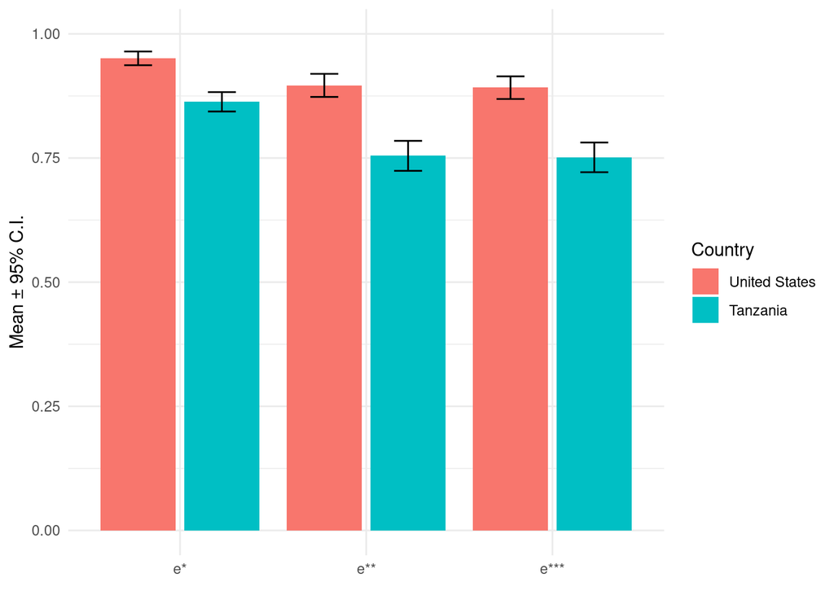

```r
fig_dta %>% filter(outcome_nm!="iq") %>%
  ggplot(aes(x=outcome_nm,
             y=mean,
             ymin = mean - 1.96 * se_mean,
             ymax = mean + 1.96 * se_mean,
             fill=country)) +
  geom_bar(orientation="x", stat="identity", position=position_dodge2()) +
  geom_errorbar(position=position_dodge(0.9), width=0.3) +
  labs(y="Mean \u00B1 95% C.I.", x= element_blank(), fill = "Country") +
  theme_minimal() +
  ylim(0, 1)
```

```r
ggsave(here("graphs", "Figure2.pdf"), width=16, height=10, units="cm")
```

Similar graph, but with standardized outcomes and including the IQ scores. We decided to change this graph into differences between countries: I make it differences between US and Tanzania.

```r
fig_dtaw <- fig_dta |>
  pivot_wider(id_cols = outcome_nm, names_from = country, values_from = c(zmean, se_zmean)) |>
  mutate( zdiff = `zmean_United States` - zmean_Tanzania,
          zdiff_se =  sqrt((`se_zmean_United States`)^2 + se_zmean_Tanzania^2 ))
```

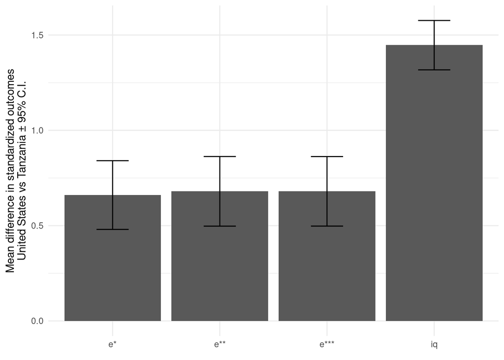

```r
fig_dtaw %>%
  ggplot(aes(x=outcome_nm,
             y=zdiff,
             ymin = zdiff - 1.96 * zdiff_se,
             ymax = zdiff + 1.96 * zdiff_se)) +
  geom_col() +
  geom_errorbar(width=0.3) +
  labs(y="Mean difference in standardized outcomes\nUnited States vs Tanzania \u00B1 95% C.I.", x= element_blank()) +
  theme_minimal()
```

```r
ggsave(here("graphs", "Figure4.pdf"), width=16, height=10, units="cm")
```

In the final figure, each of the four outcomes have been standardized to an overall average of zero and unit variance before calculating the averages by country.

The exact numbers in the graph are:

```r
fig_dtaw |> gt::gt() |>
  fmt_number(decimals = 2)
```

| outcome_nm | zmean_United States | zmean_Tanzania | se_zmean_United States | se_zmean_Tanzania | zdiff | zdiff_se |
| --- | --- | --- | --- | --- | --- | --- |
| e* | 0.42 | −0.24 | 0.05 | 0.08 | 0.66 | 0.09 |
| e** | 0.43 | −0.25 | 0.06 | 0.07 | 0.68 | 0.09 |
| e*** | 0.43 | −0.25 | 0.06 | 0.07 | 0.68 | 0.09 |
| iq | 0.91 | −0.53 | 0.03 | 0.06 | 1.45 | 0.07 |

## Survival function plot

```r
tar_load(cdf_data)
```

```
## ✖ Identified no targets to load.
```

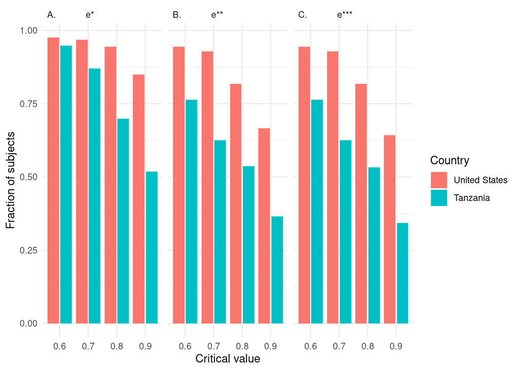

```r
tar_load(survival_gg)
survival_gg
```

```r
ggsave(here::here("graphs","Figure3.pdf"),
       width=16, height=10, units="cm")
```

# Risk aversion

For Tanzania, we are interested in whether high and low stakes individuals exhibited different risk aversion. We operationalize risk aversion by the average fraction of tokens in the cheaper security (so a high number means low risk aversion).

Now, what are the average risk aversion in the three groups?

```r
df |> group_by(country_high) |>
  summarize(mean = mean(mean_cheapest_asset),
            std.dev = sd(mean_cheapest_asset),
            se = std.dev/sqrt(n())) |>
  gt::gt() |>
  gt::fmt_number(columns=c(mean, std.dev, se), decimals=3)
```

| country_high | mean | std.dev | se |
| --- | --- | --- | --- |
| Tanzania - high | 0.592 | 0.080 | 0.008 |
| Tanzania - low | 0.617 | 0.098 | 0.010 |
| United States | 0.643 | 0.100 | 0.009 |

Testing (t-test) for equality between the treatments in Tanzania?

```r
df %>% filter(Tanzania==1) %>%
  t.test(mean_cheapest_asset ~ Treatment, data=.)
```

```
##
##  Welch Two Sample t-test
##
## data:  mean_cheapest_asset by Treatment
## t = 2.072, df = 202.72, p-value = 0.03953
## alternative hypothesis: true difference in means between group 1 and group 2 is not equal to 0
## 95 percent confidence interval:
##  0.001224164 0.049389444
## sample estimates:
## mean in group 1 mean in group 2
##       0.6169172       0.5916104
```

Testing (t-test) for equality between Tanzania low and the United States:

```r
df %>% filter(High==0) %>%
  t.test(mean_cheapest_asset ~ Tanzania, data=.)
```

```
##
##  Welch Two Sample t-test
##
## data:  mean_cheapest_asset by Tanzania
## t = 2.0283, df = 224.5, p-value = 0.04371
## alternative hypothesis: true difference in means between group 0 and group 1 is not equal to 0
## 95 percent confidence interval:
##  0.0007526184 0.0521192381
## sample estimates:
## mean in group 0 mean in group 1
##       0.6433532       0.6169172
```

In standardized units:

```r
df |> filter(Tanzania==1) |>
  lm(scale(mean_cheapest_asset) ~ Treatment, data=_)
```

```
##
## Call:
## lm(formula = scale(mean_cheapest_asset) ~ Treatment, data = filter(df,
##     Tanzania == 1))
##
## Coefficients:
## (Intercept)    Treatment
##      0.4239      -0.2809
```

```r
df |> filter(High==0) |>
  lm(scale(mean_cheapest_asset) ~ Tanzania, data=_)
```

```
##
## Call:
## lm(formula = scale(mean_cheapest_asset) ~ Tanzania, data = filter(df,
##     High == 0))
##
## Coefficients:
## (Intercept)     Tanzania
##      0.1211      -0.2652
```

Correlations between risk aversion and outcomes:

```r
df %>% group_by(country) %>%
  summarize(c_e1 = cor(mean_cheapest_asset, CCEI_PQR),
            c_e2 = cor(mean_cheapest_asset, FOSD_PQR),
            c_e3 = cor(mean_cheapest_asset, EU_PQR),
            c_IQ = cor(mean_cheapest_asset, iq)) %>%
  gt::gt() |>
  gt::fmt_number(columns=starts_with("c_"), decimals=3)
```

| Country of experiment | c_e1 | c_e2 | c_e3 | c_IQ |
| --- | --- | --- | --- | --- |
| United States | 0.066 | 0.117 | 0.124 | 0.210 |
| Tanzania | −0.025 | −0.026 | −0.022 | −0.029 |

# Main regression table: Development gap in econ rationality

```r
GARP1 <- lm(CCEI_PQR ~ Tanzania + High + age + female + one_parent_college + workincome + happy + yworried + government_preference, data=df)
GARP2 <- lm(CCEI_PQR ~ Tanzania + High + age + female + one_parent_college + workincome + happy + yworried + government_preference + BF_A + BF_C + BF_E + BF_N + BF_O , data=df)
GARP3 <- lm(CCEI_PQR ~ Tanzania + High + age + female + one_parent_college + workincome + happy + yworried + government_preference + BF_A + BF_C + BF_E + BF_N + BF_O + iq, data=df)

FGARP1 <- lm(FOSD_PQR ~ Tanzania + High + age + female + one_parent_college + workincome + happy + yworried + government_preference, data=df)
FGARP2 <- lm(FOSD_PQR ~ Tanzania + High + age + female + one_parent_college + workincome + happy + yworried + government_preference + BF_A + BF_C + BF_E + BF_N + BF_O , data=df)
FGARP3 <- lm(FOSD_PQR ~ Tanzania + High + age + female + one_parent_college + workincome + happy + yworried + government_preference + BF_A + BF_C + BF_E + BF_N + BF_O + iq, data=df)

EUT1 <- lm(EU_PQR ~ Tanzania + High + age + female + one_parent_college + workincome + happy + yworried + government_preference , data=df)
EUT2 <- lm(EU_PQR ~ Tanzania + High + age + female + one_parent_college + workincome + happy + yworried + government_preference + BF_A + BF_C + BF_E + BF_N + BF_O ,  data=df)
EUT3 <- lm(EU_PQR ~ Tanzania + High + age + female + one_parent_college + workincome + happy + yworried + government_preference + BF_A + BF_C + BF_E + BF_N + BF_O + iq, data=df)

IQ1 <- lm(iq ~ Tanzania + High + age + female + one_parent_college + workincome + happy + yworried + government_preference, data=df)
IQ2 <- lm(iq ~ Tanzania + High + age + female + one_parent_college + workincome + happy + yworried + government_preference +
              BF_A + BF_C + BF_E + BF_N + BF_O, data=df)
```

Based on these regressions, I want to add the p-value of a test that there is no difference between the US and the Tanzanian high group:

```r
ftests <- c("US equal to Tanzania high (p-val)",
            format(summary(glht(GARP1, linfct = c("Tanzania + High = 0")))$test$pvalues[1],digits=3),
            format(summary(glht(FGARP1, linfct = c("Tanzania + High = 0")))$test$pvalues[1],digits=3),
            format(summary(glht(EUT1, linfct = c("Tanzania + High = 0")))$test$pvalues[1],digits=3),
            format(summary(glht(GARP2, linfct = c("Tanzania + High = 0")))$test$pvalues[1],digits=3),
            format(summary(glht(FGARP2, linfct = c("Tanzania + High = 0")))$test$pvalues[1],digits=3),
            format(summary(glht(EUT2, linfct = c("Tanzania + High = 0")))$test$pvalues[1],digits=3),
            format(summary(glht(GARP3, linfct = c("Tanzania + High = 0")))$test$pvalues[1],digits=3),
            format(summary(glht(FGARP3, linfct = c("Tanzania + High = 0")))$test$pvalues[1],digits=3),
            format(summary(glht(EUT3, linfct = c("Tanzania + High = 0")))$test$pvalues[1],digits=3),
            format(summary(glht(IQ1, linfct = c("Tanzania + High = 0")))$test$pvalues[1],digits=3),
            format(summary(glht(IQ2, linfct = c("Tanzania + High = 0")))$test$pvalues[1],digits=3)
)
```

Also want to (manually) add row with standard deviation of outcomes.

```r
sds <- df %>% dplyr::select(CCEI_PQR, FOSD_PQR, EU_PQR, iq) |>
  summarise_all(sd)
sds |> gt::gt() |> gt::fmt_number(decimals=3)
```

| CCEI_PQR | FOSD_PQR | EU_PQR | iq |
| --- | --- | --- | --- |
| 0.133 | 0.209 | 0.206 | 0.253 |

And for the standardized effect of “Tanzania”, calculate effects

```r
Ztanzania <- c(0,
               coef(GARP1)[['Tanzania']] / sds$CCEI_PQR[1],
               coef(FGARP1)[['Tanzania']] / sds$FOSD_PQR[1],
               coef(EUT1)[['Tanzania']] / sds$EU_PQR[1],
               coef(GARP2)[['Tanzania']] / sds$CCEI_PQR[1],
               coef(FGARP2)[['Tanzania']] / sds$FOSD_PQR[1],
               coef(EUT2)[['Tanzania']] / sds$EU_PQR[1],
               coef(GARP3)[['Tanzania']] / sds$CCEI_PQR[1],
               coef(FGARP3)[['Tanzania']] / sds$FOSD_PQR[1],
               coef(EUT3)[['Tanzania']] / sds$EU_PQR[1],
               coef(IQ1)[['Tanzania']] / sds$iq,
               coef(IQ2)[['Tanzania']] / sds$iq)
Ztanzania
```

```
##  [1]  0.0000000 -0.5602489 -0.6595923 -0.6556943 -0.6323374 -0.7232109
##  [7] -0.7165680 -0.4608235 -0.4520602 -0.4542321 -1.2619261 -1.2542170
```

```r
m_names <- c('Tanzania' = 'Tanzania',
             'High' = 'High stakes (Tanzania)',
             'age' = 'Age',
             'female' = 'Female',
             'one_parent_college' = 'Parents have college education',
             'workincome' = 'Income from work?',
             'happy' = 'Happiness',
             'yworried' = 'Worried yesterday',
             'government_preferenceYes' = 'Public sector preference',
             'BF_A' = 'Agreeableness',
             'BF_C' = 'Conscientiousness',
             'BF_E' = 'Extraversion',
             'BF_N' = 'Neuroticism',
             'BF_O' = 'Openness to experience',
             'iq' = 'IQ',
             '(Intercept)' = 'Constant')
big5 <- c("Big-5 included?", "No", "No", "No", "Yes","Yes","Yes","Yes","Yes","Yes","Yes","Yes")
modelsummary::modelsummary(list("(1)"=GARP1, "(2)"=FGARP1, "(3)"=EUT1,
                                "(4)"=GARP2, "(5)"=FGARP2, "(6)"=EUT2,
                                "(7)"=GARP3, "(8)"=FGARP3, "(9)"=EUT3,
                                "(10)"=IQ1, "(11)"=IQ2),
                           statistic = "std.error", coef_map = m_names,
                           stars =  c('*' = .1, '**' = .05, '***'=0.01),
                           gof_omit = 'R2 Adj.|AIC|BIC|Log.Lik.|F|RMSE',
                           output = 'latex',
                           add_rows = as.data.frame(t(tibble(big5, Ztanzania, ftests)))) %>%
  add_header_above(c(" " = 1, "Baseline" = 3, "Baseline + Big-5" = 3,  "Baseline + Big-5 and IQ" = 3, "Cognitive ability" = 2)) %>%
  cat(file= here::here("tables/development_gap.tex"))
```

Also outputting to html record:

```r
modelsummary::modelsummary(list("(1)"=GARP1, "(2)"=FGARP1, "(3)"=EUT1,
                                "(4)"=GARP2, "(5)"=FGARP2, "(6)"=EUT2,
                                "(7)"=GARP3, "(8)"=FGARP3, "(9)"=EUT3,
                                "(10)"=IQ1, "(11)"=IQ2),
                           statistic = "std.error", coef_map = m_names,
                           stars = c('*' = .1, '**' = .05, '***'=0.01),
                           gof_omit = 'R2 Adj.|AIC|BIC|Log.Lik.|F|RMSE',
                           output = 'kableExtra',
                           add_rows = as.data.frame(t(tibble(big5, Ztanzania, ftests)))) %>%
  add_header_above(c(" " = 1, "Baseline" = 3, "Baseline + Big-5" = 3,  "Baseline + Big-5 and IQ" = 3, "Cognitive ability" = 2))
```

|  | Baseline (1) | Baseline (2) | Baseline (3) | Baseline + Big-5 (4) | Baseline + Big-5 (5) | Baseline + Big-5 (6) | Baseline + Big-5 and IQ (7) | Baseline + Big-5 and IQ (8) | Baseline + Big-5 and IQ (9) | Cognitive ability (10) | Cognitive ability (11) |
| --- | --- | --- | --- | --- | --- | --- | --- | --- | --- | --- | --- |
| Tanzania | −0.074*** | −0.138*** | −0.135*** | −0.084*** | −0.151*** | −0.148*** | −0.061** | −0.094** | −0.094** | −0.320*** | −0.318*** |
|  | (0.020) | (0.031) | (0.031) | (0.021) | (0.034) | (0.033) | (0.024) | (0.038) | (0.038) | (0.029) | (0.032) |
| High stakes (Tanzania) | 0.014 | 0.053** | 0.050* | 0.012 | 0.050* | 0.048* | 0.014 | 0.055** | 0.052** | −0.023 | −0.024 |
|  | (0.017) | (0.026) | (0.026) | (0.017) | (0.027) | (0.026) | (0.017) | (0.026) | (0.026) | (0.025) | (0.025) |
| Age | −0.003 | −0.004 | −0.004 | −0.002 | −0.004 | −0.004 | −0.002 | −0.004 | −0.004 | −0.002 | −0.002 |
|  | (0.002) | (0.004) | (0.003) | (0.002) | (0.004) | (0.004) | (0.002) | (0.004) | (0.003) | (0.003) | (0.003) |
| Female | 0.009 | 0.014 | 0.015 | 0.007 | 0.011 | 0.012 | 0.004 | 0.004 | 0.006 | 0.038* | 0.038* |
|  | (0.015) | (0.023) | (0.023) | (0.015) | (0.023) | (0.023) | (0.015) | (0.023) | (0.023) | (0.022) | (0.022) |
| Parents have college education | 0.015 | 0.014 | 0.013 | 0.018 | 0.020 | 0.019 | 0.016 | 0.016 | 0.015 | 0.023 | 0.022 |
|  | (0.016) | (0.025) | (0.024) | (0.016) | (0.025) | (0.025) | (0.016) | (0.025) | (0.025) | (0.023) | (0.024) |
| Income from work? | 0.014 | 0.026 | 0.026 | 0.013 | 0.025 | 0.025 | 0.014 | 0.026 | 0.026 | −0.004 | −0.005 |
|  | (0.019) | (0.031) | (0.030) | (0.020) | (0.032) | (0.031) | (0.020) | (0.031) | (0.031) | (0.029) | (0.030) |
| Happiness | −0.001 | 0.003 | 0.003 | −0.002 | 0.002 | 0.002 | −0.002 | 0.001 | 0.001 | 0.005 | 0.005 |
|  | (0.003) | (0.004) | (0.004) | (0.003) | (0.004) | (0.004) | (0.003) | (0.004) | (0.004) | (0.004) | (0.004) |
| Worried yesterday | −0.034** | −0.060** | −0.058** | −0.029* | −0.056** | −0.053* | −0.029* | −0.056** | −0.053** | −0.002 | 0.001 |
|  | (0.016) | (0.026) | (0.026) | (0.017) | (0.027) | (0.027) | (0.017) | (0.027) | (0.027) | (0.024) | (0.026) |
| Public sector preference | 0.004 | 0.013 | 0.013 | 0.003 | 0.013 | 0.012 | 0.004 | 0.015 | 0.015 | −0.014 | −0.013 |
|  | (0.014) | (0.023) | (0.023) | (0.015) | (0.023) | (0.023) | (0.014) | (0.023) | (0.022) | (0.021) | (0.022) |
| Agreeableness |  |  |  | 0.024 | 0.016 | 0.021 | 0.026 | 0.022 | 0.026 |  | −0.033 |
|  |  |  |  | (0.020) | (0.032) | (0.032) | (0.020) | (0.032) | (0.031) |  | (0.030) |
| Conscientiousness |  |  |  | 0.011 | 0.031 | 0.029 | 0.011 | 0.030 | 0.028 |  | 0.005 |
|  |  |  |  | (0.017) | (0.028) | (0.027) | (0.017) | (0.027) | (0.027) |  | (0.026) |
| Extraversion |  |  |  | 0.004 | −0.011 | −0.012 | 0.005 | −0.009 | −0.010 |  | −0.012 |
|  |  |  |  | (0.016) | (0.025) | (0.025) | (0.016) | (0.025) | (0.025) |  | (0.024) |
| Neuroticism |  |  |  | −0.006 | −0.003 | −0.003 | −0.004 | 0.000 | 0.001 |  | −0.020 |
|  |  |  |  | (0.017) | (0.027) | (0.027) | (0.017) | (0.027) | (0.027) |  | (0.026) |
| Openness to experience |  |  |  | −0.002 | 0.006 | 0.008 | −0.002 | 0.005 | 0.007 |  | 0.005 |
|  |  |  |  | (0.019) | (0.030) | (0.030) | (0.019) | (0.030) | (0.029) |  | (0.028) |
| IQ |  |  |  |  |  |  | 0.072* | 0.178*** | 0.170*** |  |  |
|  |  |  |  |  |  |  | (0.037) | (0.058) | (0.058) |  |  |
| Constant | 0.994*** | 0.951*** | 0.941*** | 0.979*** | 0.923*** | 0.910*** | 0.918*** | 0.774*** | 0.767*** | 0.826*** | 0.841*** |
|  | (0.055) | (0.086) | (0.085) | (0.058) | (0.091) | (0.090) | (0.065) | (0.102) | (0.101) | (0.081) | (0.086) |
| Num.Obs. | 337 | 337 | 337 | 337 | 337 | 337 | 337 | 337 | 337 | 337 | 337 |
| R2 | 0.122 | 0.140 | 0.139 | 0.131 | 0.146 | 0.146 | 0.141 | 0.170 | 0.168 | 0.504 | 0.506 |
| Big-5 included? | No | No | No | Yes | Yes | Yes | Yes | Yes | Yes | Yes | Yes |
| 0.0000000 | -0.5602489 | -0.6595923 | -0.6556943 | -0.6323374 | -0.7232109 | -0.7165680 | -0.4608235 | -0.4520602 | -0.4542321 | -1.2619261 | -1.2542170 |
| US equal to Tanzania high (p-val) | 0.00243 | 0.00671 | 0.00617 | 0.00091 | 0.00315 | 0.003 | 0.0586 | 0.309 | 0.28 | 0 | 0 |

* p < 0.1, ** p < 0.05, *** p < 0.01

And what are the correlations between IQ and the rationalizability measurses in the US, in Tanzania low and Tanzania high stakes?

```r
df |> group_by(country_high) |>
  summarize(cor_IQ_CCEI = cor(iq, CCEI_PQR),
            cor_IQ_FOSD = cor(iq, FOSD_PQR),
            cor_IQ_EU= cor(iq, EU_PQR)) |>
  gt::gt() |>
  gt::fmt_number(decimals=3)
```

| country_high | cor_IQ_CCEI | cor_IQ_FOSD | cor_IQ_EU |
| --- | --- | --- | --- |
| Tanzania - high | 0.178 | 0.228 | 0.217 |
| Tanzania - low | 0.040 | 0.116 | 0.115 |
| United States | 0.061 | 0.120 | 0.120 |

# More descriptives about the Tanzania sample

# Further analysis (for appendix)

## CDF graphs for outcomes

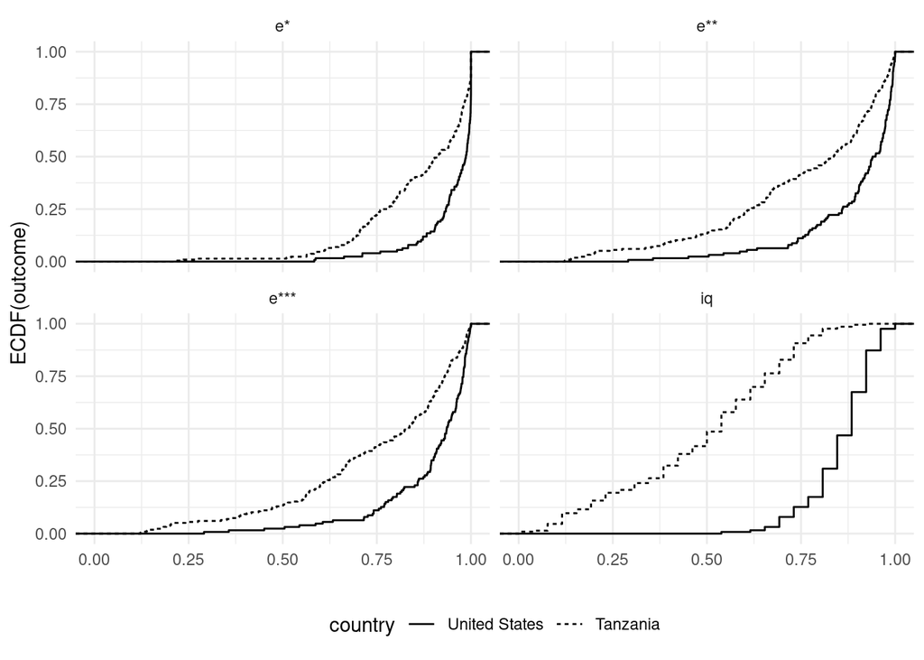

```r
tar_load(cdf_dta)
cdf_dta %>% ggplot(aes(x=value, linetype=country)) +
  stat_ecdf(geom="step") +
  facet_wrap(.~yfct) +
  theme_minimal() +
  theme(legend.position="bottom") +
  labs(y = "ECDF(outcome)", x=element_blank())
```

```r
ggsave(here("graphs", "cdf_outcomes.pdf"), width=16, height = 10, units = "cm")
```

## Variant of Table I from main paper with risk aversion and everything

```r
rGARP1 <- lm(CCEI_PQR ~ Tanzania + High + mean_cheapest_asset + age + female + one_parent_college + workincome + happy + yworried + government_preference + gambling + funding_education , data=df)
rGARP2 <- lm(CCEI_PQR ~ Tanzania + High + mean_cheapest_asset + age + female + one_parent_college + workincome + happy + yworried + government_preference + gambling + funding_education  + BF_A + BF_C + BF_E + BF_N + BF_O , data=df)
rGARP3 <- lm(CCEI_PQR ~ Tanzania + High + mean_cheapest_asset + age + female + one_parent_college + workincome + happy + yworried + government_preference + gambling + funding_education  + BF_A + BF_C + BF_E + BF_N + BF_O + iq, data=df)

rFGARP1 <- lm(FOSD_PQR ~ Tanzania + High + mean_cheapest_asset + age + female + one_parent_college + workincome + happy + yworried + government_preference + gambling + funding_education , data=df)
rFGARP2 <- lm(FOSD_PQR ~ Tanzania + High + mean_cheapest_asset + age + female + one_parent_college + workincome + happy + yworried + government_preference + gambling + funding_education  + BF_A + BF_C + BF_E + BF_N + BF_O , data=df)
rFGARP3 <- lm(FOSD_PQR ~ Tanzania + High + mean_cheapest_asset + age + female + one_parent_college + workincome + happy + yworried + government_preference + gambling + funding_education  + BF_A + BF_C + BF_E + BF_N + BF_O + iq, data=df)

rEUT1 <- lm(EU_PQR ~ Tanzania + High + mean_cheapest_asset + age + female + one_parent_college + workincome + happy + yworried + government_preference + gambling + funding_education  , data=df)
rEUT2 <- lm(EU_PQR ~ Tanzania + High + mean_cheapest_asset + age + female + one_parent_college + workincome + happy + yworried + government_preference + gambling + funding_education  + BF_A + BF_C + BF_E + BF_N + BF_O ,  data=df)
rEUT3 <- lm(EU_PQR ~ Tanzania + High + mean_cheapest_asset + age + female + one_parent_college + workincome + happy + yworried + government_preference + gambling + funding_education  + BF_A + BF_C + BF_E + BF_N + BF_O + iq, data=df)

rIQ1 <- lm(iq ~ Tanzania + High + mean_cheapest_asset + age + female + one_parent_college + workincome + happy + yworried + government_preference + gambling + funding_education , data=df)
rIQ2 <- lm(iq ~ Tanzania + High + mean_cheapest_asset + age + female + one_parent_college + workincome + happy + yworried + government_preference + gambling + funding_education  +
              BF_A + BF_C + BF_E + BF_N + BF_O, data=df)
```

```r
rm_names <- c('Tanzania' = 'Tanzania',
             'High' = 'High stakes (Tanzania)',
             'mean_cheapest_asset' = 'Risk aversion',
             'age' = 'Age',
             'female' = 'Female',
             'one_parent_college' = 'Parents have college education',
             'workincome' = 'Income from work?',
             'happy' = 'Happiness',
             'yworried' = 'Worried yesterday',
             'government_preferenceYes' = 'Public sector preference',
             'gambling' = 'Self image as gambler',
             'funding_educationYes' = 'Would spend money on education',
             'iq' = 'IQ',
             '(Intercept)' = 'Constant')
modelsummary::modelsummary(list("(1)"=rGARP1, "(2)"=rFGARP1, "(3)"=rEUT1,
                                "(4)"=rGARP2, "(5)"=rFGARP2, "(6)"=rEUT2,
                                "(7)"=rGARP3, "(8)"=rFGARP3, "(9)"=rEUT3,
                                "(10)"=rIQ1, "(11)"=rIQ2),
                           statistic = "std.error", coef_map = rm_names,
                           stars =  c('*' = .1, '**' = .05, '***'=0.01),
                           gof_omit = 'R2 Adj.|AIC|BIC|Log.Lik.|F|RMSE',
                           output = 'latex',
                           add_rows = as.data.frame(t(big5))) %>%
  add_header_above(c(" " = 1, "Baseline" = 3, "Baseline + Big-5" = 3,  "Baseline + Big-5 and IQ" = 3, "Cognitive ability" = 2)) %>%
  cat(file= here::here("tables/development_gap_withrisk.tex"))
```

Also outputting to html record:

```r
modelsummary::modelsummary(list("(1)"=rGARP1, "(2)"=rFGARP1, "(3)"=rEUT1,
                                "(4)"=rGARP2, "(5)"=rFGARP2, "(6)"=rEUT2,
                                "(7)"=rGARP3, "(8)"=rFGARP3, "(9)"=rEUT3,
                                "(10)"=rIQ1, "(11)"=rIQ2),
                           statistic = "std.error", coef_map = rm_names,
                           stars = c('*' = .1, '**' = .05, '***'=0.01),
                           gof_omit = 'R2 Adj.|AIC|BIC|Log.Lik.|F|RMSE',
                           output = 'kableExtra',
                           add_rows = as.data.frame(t(big5))) %>%
  add_header_above(c(" " = 1, "Baseline" = 3, "Baseline + Big-5" = 3,  "Baseline + Big-5 and IQ" = 3, "Cognitive ability" = 2))
```

|  | Baseline (1) | Baseline (2) | Baseline (3) | Baseline + Big-5 (4) | Baseline + Big-5 (5) | Baseline + Big-5 (6) | Baseline + Big-5 and IQ (7) | Baseline + Big-5 and IQ (8) | Baseline + Big-5 and IQ (9) | Cognitive ability (10) | Cognitive ability (11) |
| --- | --- | --- | --- | --- | --- | --- | --- | --- | --- | --- | --- |
| Tanzania | −0.073*** | −0.134*** | −0.131*** | −0.081*** | −0.147*** | −0.144*** | −0.058** | −0.090** | −0.089** | −0.320*** | −0.319*** |
|  | (0.020) | (0.032) | (0.031) | (0.022) | (0.034) | (0.034) | (0.025) | (0.039) | (0.038) | (0.030) | (0.032) |
| High stakes (Tanzania) | 0.013 | 0.051* | 0.049* | 0.010 | 0.049* | 0.047* | 0.012 | 0.053** | 0.050* | −0.022 | −0.023 |
|  | (0.017) | (0.027) | (0.026) | (0.017) | (0.027) | (0.027) | (0.017) | (0.027) | (0.026) | (0.025) | (0.025) |
| Risk aversion | −0.046 | −0.014 | −0.003 | −0.048 | −0.008 | 0.004 | −0.051 | −0.016 | −0.003 | 0.055 | 0.045 |
|  | (0.073) | (0.115) | (0.114) | (0.074) | (0.117) | (0.116) | (0.074) | (0.116) | (0.115) | (0.109) | (0.111) |
| Age | −0.002 | −0.004 | −0.004 | −0.002 | −0.004 | −0.004 | −0.002 | −0.003 | −0.003 | −0.002 | −0.002 |
|  | (0.002) | (0.004) | (0.004) | (0.002) | (0.004) | (0.004) | (0.002) | (0.004) | (0.004) | (0.003) | (0.003) |
| Female | 0.007 | 0.014 | 0.015 | 0.006 | 0.011 | 0.013 | 0.003 | 0.004 | 0.006 | 0.040* | 0.039* |
|  | (0.015) | (0.023) | (0.023) | (0.015) | (0.023) | (0.023) | (0.015) | (0.023) | (0.023) | (0.022) | (0.022) |
| Parents have college education | 0.015 | 0.016 | 0.014 | 0.018 | 0.021 | 0.020 | 0.017 | 0.017 | 0.016 | 0.022 | 0.022 |
|  | (0.016) | (0.025) | (0.025) | (0.016) | (0.025) | (0.025) | (0.016) | (0.025) | (0.025) | (0.023) | (0.024) |
| Income from work? | 0.015 | 0.025 | 0.025 | 0.014 | 0.024 | 0.024 | 0.015 | 0.025 | 0.025 | −0.005 | −0.006 |
|  | (0.020) | (0.031) | (0.031) | (0.020) | (0.032) | (0.032) | (0.020) | (0.032) | (0.031) | (0.029) | (0.030) |
| Happiness | −0.001 | 0.003 | 0.003 | −0.002 | 0.002 | 0.003 | −0.002 | 0.001 | 0.002 | 0.005 | 0.005 |
|  | (0.003) | (0.004) | (0.004) | (0.003) | (0.005) | (0.004) | (0.003) | (0.004) | (0.004) | (0.004) | (0.004) |
| Worried yesterday | −0.034** | −0.059** | −0.056** | −0.028 | −0.053* | −0.050* | −0.028 | −0.053* | −0.050* | −0.002 | 0.000 |
|  | (0.017) | (0.026) | (0.026) | (0.017) | (0.028) | (0.027) | (0.017) | (0.027) | (0.027) | (0.025) | (0.026) |
| Public sector preference | 0.002 | 0.011 | 0.011 | 0.001 | 0.010 | 0.010 | 0.002 | 0.012 | 0.012 | −0.013 | −0.012 |
|  | (0.015) | (0.023) | (0.023) | (0.015) | (0.023) | (0.023) | (0.015) | (0.023) | (0.023) | (0.022) | (0.022) |
| Self image as gambler | −0.005 | −0.003 | −0.003 | −0.003 | −0.001 | −0.001 | −0.003 | −0.001 | −0.001 | 0.002 | 0.002 |
|  | (0.005) | (0.008) | (0.008) | (0.005) | (0.008) | (0.008) | (0.005) | (0.008) | (0.008) | (0.007) | (0.008) |
| Would spend money on education | 0.012 | 0.020 | 0.022 | 0.014 | 0.023 | 0.024 | 0.015 | 0.025 | 0.026 | −0.010 | −0.010 |
|  | (0.014) | (0.022) | (0.021) | (0.014) | (0.022) | (0.021) | (0.014) | (0.021) | (0.021) | (0.020) | (0.021) |
| IQ |  |  |  |  |  |  | 0.074** | 0.180*** | 0.173*** |  |  |
|  |  |  |  |  |  |  | (0.037) | (0.059) | (0.058) |  |  |
| Constant | 1.025*** | 0.945*** | 0.925*** | 1.008*** | 0.907*** | 0.883*** | 0.948*** | 0.760*** | 0.743*** | 0.792*** | 0.814*** |
|  | (0.079) | (0.124) | (0.123) | (0.083) | (0.131) | (0.130) | (0.088) | (0.138) | (0.137) | (0.117) | (0.124) |
| Num.Obs. | 337 | 337 | 337 | 337 | 337 | 337 | 337 | 337 | 337 | 337 | 337 |
| R2 | 0.127 | 0.143 | 0.142 | 0.136 | 0.149 | 0.149 | 0.147 | 0.174 | 0.172 | 0.504 | 0.507 |
| Big-5 included? | No | No | No | Yes | Yes | Yes | Yes | Yes | Yes | Yes | Yes |

* p < 0.1, ** p < 0.05, *** p < 0.01

## Treatment effect of stakes on rationalizability (in Tanzania)

```r
t_names <- c('High' = 'High stakes',
             'mean_cheapest_asset' = 'Risk aversion',
             'age' = 'Age',
             'female' = 'Female',
             'one_parent_college' = 'Parents have college education',
             'workincome' = 'Income from work?',
             'happy' = 'Happiness',
             'yworried' = 'Worried yesterday',
             'government_preferenceYes' = 'Public sector preference',
             'iq' = 'IQ',
             '(Intercept)' = 'Constant')
t_big5 <- c("Big-5 included?", "No", "No", "No", "Yes","Yes","Yes", "Yes","Yes","Yes")
modelsummary::modelsummary(list("(1)"=tGARP1, "(2)"=tFGARP1, "(3)"=tEUT1,
                                "(4)"=tGARP2, "(5)"=tFGARP2, "(6)"=tEUT2,
                                "(7)"=tGARP3, "(8)"=tFGARP3, "(9)"=tEUT3),
                           statistic = "std.error", coef_map = t_names,
                           stars = c('*' = .1, '**' = .05, '***'=0.01),
                           gof_omit = 'R2 Adj.|AIC|BIC|Log.Lik.|F|RMSE',
                           output = 'latex',
                           add_rows = as.data.frame(t(t_big5))) |>
  add_header_above(c(" " = 1, "No controls" = 3, "Baseline controls w. Big-5" = 3,  "Baseline controls w. Big-5 and IQ" = 3)) %>%
  cat(file= here::here("tables/treatmenteffect_stakes.tex"))
```

Also outputting to html record:

```r
modelsummary::modelsummary(list("(1)"=tGARP1, "(2)"=tFGARP1, "(3)"=tEUT1,
                                "(4)"=tGARP2, "(5)"=tFGARP2, "(6)"=tEUT2,
                                "(7)"=tGARP3, "(8)"=tFGARP3, "(9)"=tEUT3),
                           statistic = "std.error", coef_map = t_names,
                           stars = c('*' = .1, '**' = .05, '***'=0.01),
                           gof_omit = 'R2 Adj.|AIC|BIC|Log.Lik.|F|RMSE',
                           output = 'kableExtra',
                           add_rows = as.data.frame(t(t_big5))) %>%
  add_header_above(c(" " = 1, "No controls" = 3, "Baseline controls w. Big-5" = 3,  "Baseline controls w. Big-5 and IQ" = 3))
```

|  | No controls (1) | No controls (2) | No controls (3) | Baseline controls w. Big-5 (4) | Baseline controls w. Big-5 (5) | Baseline controls w. Big-5 (6) | Baseline controls w. Big-5 and IQ (7) | Baseline controls w. Big-5 and IQ (8) | Baseline controls w. Big-5 and IQ (9) |
| --- | --- | --- | --- | --- | --- | --- | --- | --- | --- |
| High stakes | 0.012 | 0.043 | 0.041 | 0.012 | 0.050 | 0.048 | 0.013 | 0.054* | 0.052* |
|  | (0.020) | (0.031) | (0.030) | (0.020) | (0.031) | (0.031) | (0.020) | (0.031) | (0.031) |
| Age |  |  |  | −0.005 | −0.008 | −0.008 | −0.005 | −0.009 | −0.008 |
|  |  |  |  | (0.005) | (0.008) | (0.008) | (0.005) | (0.008) | (0.008) |
| Female |  |  |  | 0.023 | 0.024 | 0.027 | 0.017 | 0.010 | 0.013 |
|  |  |  |  | (0.022) | (0.035) | (0.034) | (0.022) | (0.035) | (0.034) |
| Parents have college education |  |  |  | 0.029 | 0.034 | 0.031 | 0.027 | 0.029 | 0.026 |
|  |  |  |  | (0.023) | (0.035) | (0.035) | (0.022) | (0.035) | (0.035) |
| Income from work? |  |  |  | 0.010 | −0.005 | −0.002 | 0.007 | −0.014 | −0.010 |
|  |  |  |  | (0.041) | (0.064) | (0.063) | (0.041) | (0.063) | (0.063) |
| Happiness |  |  |  | −0.003 | 0.001 | 0.001 | −0.003 | 0.000 | 0.000 |
|  |  |  |  | (0.004) | (0.006) | (0.006) | (0.004) | (0.006) | (0.005) |
| Worried yesterday |  |  |  | −0.028 | −0.054 | −0.053 | −0.028 | −0.055 | −0.054 |
|  |  |  |  | (0.027) | (0.043) | (0.043) | (0.027) | (0.042) | (0.042) |
| Public sector preference |  |  |  | −0.014 | −0.006 | −0.006 | −0.014 | −0.006 | −0.006 |
|  |  |  |  | (0.022) | (0.034) | (0.034) | (0.022) | (0.034) | (0.033) |
| IQ |  |  |  |  |  |  | 0.075 | 0.189*** | 0.180** |
|  |  |  |  |  |  |  | (0.046) | (0.071) | (0.071) |
| Constant | 0.857*** | 0.733*** | 0.731*** | 0.914*** | 0.828*** | 0.814*** | 0.885*** | 0.753*** | 0.744*** |
|  | (0.014) | (0.022) | (0.022) | (0.130) | (0.205) | (0.203) | (0.131) | (0.204) | (0.202) |
| Num.Obs. | 216 | 216 | 216 | 211 | 211 | 211 | 211 | 211 | 211 |
| R2 | 0.002 | 0.009 | 0.008 | 0.056 | 0.058 | 0.058 | 0.069 | 0.090 | 0.088 |
| Big-5 included? | No | No | No | Yes | Yes | Yes | Yes | Yes | Yes |

* p < 0.1, ** p < 0.05, *** p < 0.01

## Treatment effect of (high) stakes on risk aversion (in Tanzania)

```r
r_names <- c('High' = 'High stakes',
             'mean_cheapest_asset' = 'Risk aversion',
             'age' = 'Age',
             'female' = 'Female',
             'one_parent_college' = 'Parents have college education',
             'workincome' = 'Income from work?',
             'happy' = 'Happiness',
             'yworried' = 'Worried yesterday',
             'government_preferenceYes' = 'Public sector preference',
             'iq' = 'IQ',
             '(Intercept)' = 'Constant')


r_big5 <- c("Big-5 included?", "No","Yes","Yes")
modelsummary::modelsummary(list("(1)"=r1, "(2)"=r2, "(3)"=r3),
                           statistic = "std.error", coef_map = r_names,
                           stars = c('*' = .1, '**' = .05, '***'=0.01),
                           gof_omit = 'R2 Adj.|AIC|BIC|Log.Lik.|F|RMSE',
                           add_rows = as.data.frame(t(r_big5)),
                           output = 'latex') |>
  add_header_above(c(" ","Mean share cheapest asset"=3)) |>
  cat(file= here::here("tables/treatmenteffect_riskaversion.tex"))
```

Also outputting to html record:

```r
modelsummary::modelsummary(list("(1)"=r1, "(2)"=r2, "(3)"=r3),
                           statistic = "std.error", coef_map = r_names,
                           stars = c('*' = .1, '**' = .05, '***'=0.1),
                           gof_omit = 'R2 Adj.|AIC|BIC|Log.Lik.|F|RMSE',
                           add_rows = as.data.frame(t(r_big5)),
                           output = 'kableExtra') %>%
  add_header_above(c(" ","Mean share cheapest asset"=3))
```

|  | Mean share cheapest asset (1) | Mean share cheapest asset (2) | Mean share cheapest asset (3) |
| --- | --- | --- | --- |
| High stakes | −0.025** | −0.022*** | −0.023*** |
|  | (0.012) | (0.013) | (0.013) |
| Age |  | −0.001 | −0.001 |
|  |  | (0.003) | (0.003) |
| Female |  | 0.005 | 0.006 |
|  |  | (0.014) | (0.014) |
| Parents have college education |  | −0.010 | −0.010 |
|  |  | (0.014) | (0.014) |
| Income from work? |  | 0.040 | 0.041 |
|  |  | (0.026) | (0.026) |
| Happiness |  | −0.004 | −0.004 |
|  |  | (0.002) | (0.002) |
| Worried yesterday |  | −0.007 | −0.007 |
|  |  | (0.018) | (0.018) |
| Public sector preference |  | −0.002 | −0.002 |
|  |  | (0.014) | (0.014) |
| IQ |  |  | −0.016 |
|  |  |  | (0.030) |
| Constant | 0.617** | 0.646** | 0.653** |
|  | (0.009) | (0.083) | (0.084) |
| Num.Obs. | 216 | 211 | 211 |
| R2 | 0.020 | 0.062 | 0.064 |
| Big-5 included? | No | Yes | Yes |

* p < 0.1, *** p < 0.1, ** p < 0.05

## Distribution of happiness

First, the averages:

```r
df |> group_by(country) |>
  summarize(mean_happiness = mean(happy, na.rm=TRUE)) |>
  gt::gt() |> gt::fmt_number(decimals=3)
```

| Country of experiment | mean_happiness |
| --- | --- |
| United States | 7.413 |
| Tanzania | 6.640 |

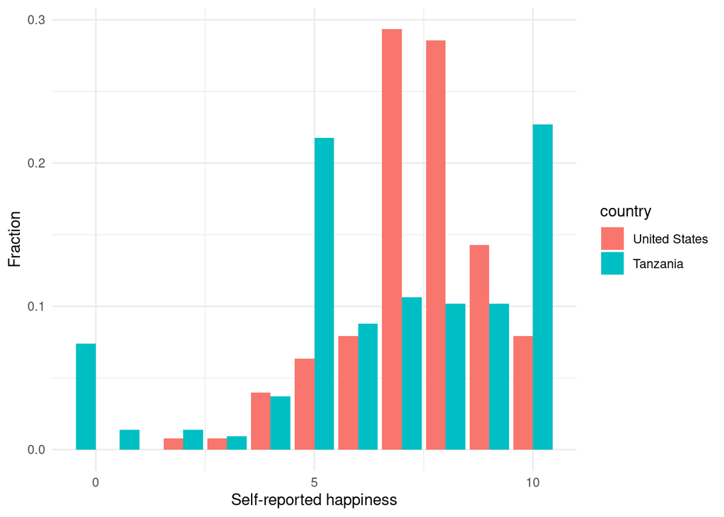

```r
df |> group_by(country, happy) |>
  summarize( freq = n()) |>
  group_by(country) |>
  mutate(proportion = freq / sum(freq)) |>
  ggplot(aes(x=happy, y = proportion, fill=country)) +
  geom_bar(stat='identity', position = position_dodge(preserve = "single"), width=0.9, preserve='single') +
  labs(x = "Self-reported happiness", y="Fraction") +
  scale_x_continuous(breaks = c(0,5,10)) +
  theme_minimal()
```

```r
ggsave(here::here("graphs","happiness_distribution.pdf"), width=16, height=10, units="cm")
```

## Breaking down by preference for public sector

The question asked was

> Assume that you could choose between the following job opportunities, and that income and work hours were exactly the same in all of them. How would you rate these jobs?

They then rated “government employee” on a 1 (not so good) to 3 (very good) scale. Breaking down such that 3 is an active preference from being a government employee:

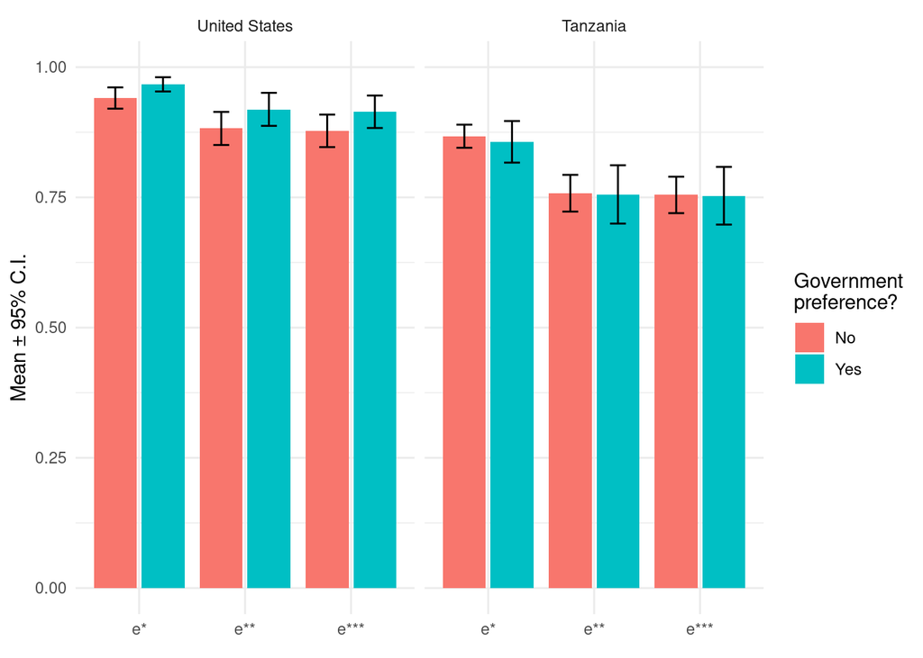

```r
tar_load(pubpreffig_dta)
pubpreffig_dta |>
  ggplot(aes(x=outcome_nm,
             y=mean,
             ymin = mean - 1.96 * se_mean,
             ymax = mean + 1.96 * se_mean,
             fill=government_preference)) +
  geom_bar(orientation="x", stat="identity", position=position_dodge2()) +
  geom_errorbar(position=position_dodge(0.9), width=0.3) +
  labs(y="Mean \u00B1 95% C.I.", x= element_blank(), fill = "Government\npreference?") +
  theme_minimal() +
  ylim(0, 1) +
  facet_wrap(. ~ country)
```

```r
ggsave(here("graphs", "government_preference.pdf"), width=16, height=10, units="cm")
```